# Financial Market

Session 2

Luis F. Gómez L.

luis.gomezl@unimilitar.edu.co

Distance Learning Faculty

10 February, 2026

# Please Read Me

- Check the message **Welcome greeting** published in Announcements forum.
- Dear student please edit your profile uploading a photo where your face is clearly visible.
- If you want to participate, please fill out the following survey: **Primer corte 30% > Learning Activities > Tu opinión sobre la economía colombiana**
- This presentation is based on (Cardenas, 2020, Chapter 8)
- **Purpose**
  - Analyze the functioning of the financial market, identifying the types of intermediaries and instruments that are part of it

# Principal instruments *“Mercado no intermediado”*

- **Fixed income (Renta fija)**: provides returns in the form of regular interest payments and repayments of the principal
  - Títulos de tesorería (TES)
    - Debt securities issued by the national government and administered by the Banco de la República.
    - The national government use this instrument to finance its activities
  - Certificados de Depósito a Término (CDT)

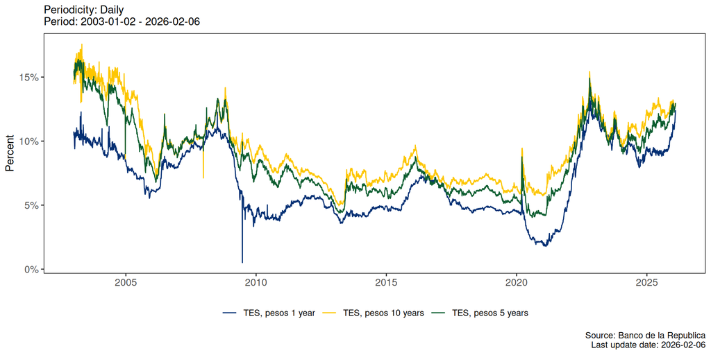

Figure 1: Interest rates TES zero coupon (COP, 1, 5 and 10 years)

- TES zero coupon
  - Actual bond price: $P$
  - Nominal value: $NV$ where $P < NV$
  - Term: $n$
  - Interest rate: $i$

$$\begin{split}
P & = \frac{NV}{(1 + i)^n} \\
(1 + i)^n & = \frac{NV}{P} \\
i & = \left( \frac{NV}{P} \right)^{\frac{1}{n}} - 1 \\
\end{split}$$

- An example: TES zero coupon
  - Actual bond price: $P = 600000$
  - Nominal value: $NV = 1000000$
  - Term: $n = 10$

$$\begin{split}
i & = \left( \frac{NV}{P} \right)^{\frac{1}{n}} - 1 \\
& = \left( \frac{1000000}{600000} \right)^{\frac{1}{10}} - 1 \\
& \approx 0.0524 \text{ (5.24 \%)}
\end{split}$$

- **Equity (Renta variable)**:
  - Shares/Stocks
    - These instruments are issued by companies to raise funds from the general public
    - They represent a fractional ownership in the company that issue them
    - If the company does well, its value may increase, and the value of your shares may also rise. You can then sell your shares for a profit. If the company performs poorly, the value of your shares may decrease, and you could lose money.
    - Some companies share their profits with shareholders by paying dividends.
    - The decision to pay dividends or reinvest the profist rests with the company’s board of directors. Whether a company pays dividends or reinvests its profits depends on its specific circumstances and strategic goals.

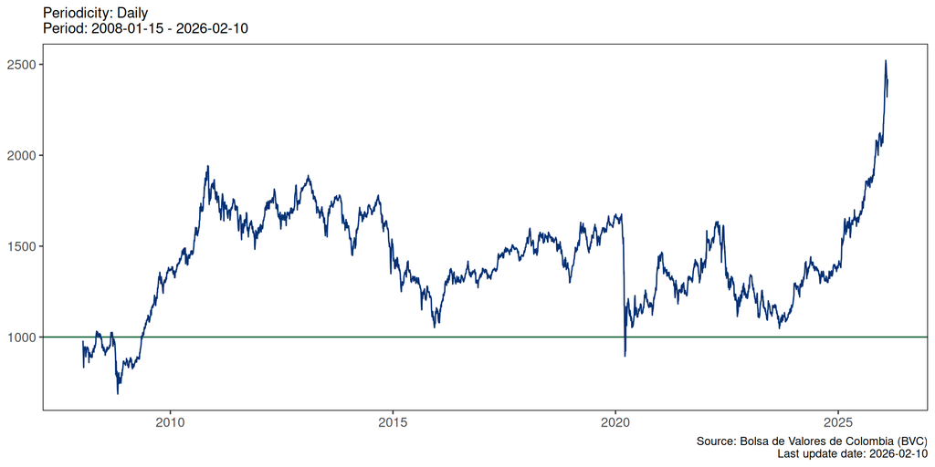

Figure 2: MSCI COLCAP Index

Table 1: Current MSCI COLCAP Index basket

| Ticker | Legal Name | Percent |
| --- | --- | --- |
| PFCIBEST | GRUPO CIBEST SA | 23.66 |
| CIBEST | GRUPO CIBEST SA | 15.01 |
| ISA | INTERCONEXION ELECTRICA S.A. E.S.P. | 9.33 |
| ECOPETROL | ECOPETROL S.A. | 7.96 |
| CEMARGOS | CEMENTOS ARGOS S.A. | 6.32 |
| GEB | GRUPO ENERGIA BOGOTA S.A. E.S.P. | 5.75 |
| PFGRUPSURA | GRUPO INVERSIONES SURAMERICANA | 5.70 |
| GRUPOSURA | GRUPO INVERSIONES SURAMERICANA | 5.41 |
| GRUPOARGOS | GRUPO ARGOS S.A. | 4.19 |
| PFGRUPOARG | GRUPO ARGOS S.A. | 2.84 |
| PFAVAL | GRUPO AVAL ACCIONES Y VALORES S.A. | 2.43 |

Source: BVC - Bolsa de Valores de Colombia  
Last update: 2026-02-10

Table 2: Current MSCI COLCAP Index basket

| Ticker | Legal Name | Percent |
| --- | --- | --- |
| PFDAVIGRP | DAVIVIENDA GROUP SA | 2.20 |
| CELSIA | CELSIA S.A | 1.67 |
| PEI | PATRIMONIO AUTONOMO DE ESTRATEGIAS INMOBILIARIAS | 1.47 |
| CORFICOLCF | CORPORACION FINANCIERA COLOMBIANA S.A. | 1.23 |
| MINEROS | MINEROS S.A. | 1.21 |
| GRUBOLIVAR | GRUPO BOLIVAR S.A. | 1.08 |
| BOGOTA | BANCO DE BOGOTA S.A. | 0.74 |
| PROMIGAS | PROMIGAS S.A. E.S.P. | 0.55 |
| TERPEL | ORGANIZACION TERPEL S.A | 0.51 |
| EXITO | ALMACENES EXITO S.A. | 0.50 |
| PFCORFICOL | CORPORACION FINANCIERA COLOMBIANA S.A. | 0.22 |

Source: BVC - Bolsa de Valores de Colombia  
Last update: 2026-02-10

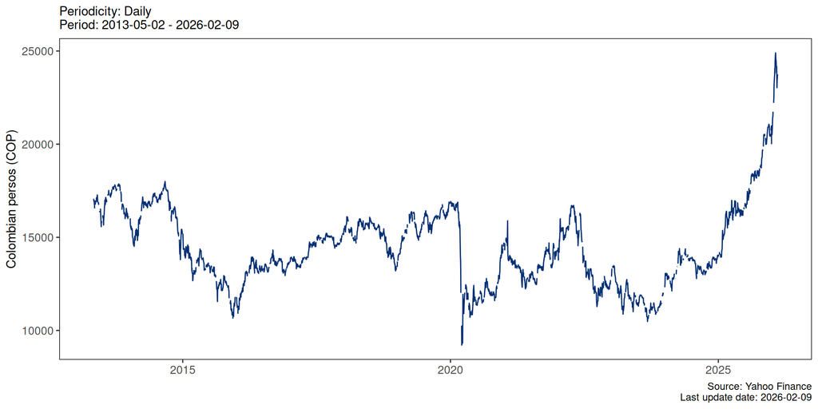

Figure 3: iShares MSCI COLCAP Exchange-Traded Fund (ETF)

# Banking market or *“Mercado Intermediado”*

- **What is a bank?**
  - *“A bank is an institution **whose current operations** consist in granting loans and receiving deposits from the public”* (Freixas & Rochet, 2008, p. 1)
    - Therefore the core activities of banks are related to deposits and loans
- **What functions banks perform?** (Freixas & Rochet, 2008, p. 2)
  - Offering liquidity and payment services
  - Transforming assets
  - Managing risks
  - Processing information and monitoring borrowers
- **Offering liquidity and payment services** (Freixas & Rochet, 2008, pp. 2–4)
  - Banks offer short term credits to companies and individuals and have created networks that facilitate the transfer of funds between the bank accounts of economic agents
- **Transforming assets** (Freixas & Rochet, 2008, pp. 5–6)
  - **Convenience of denomination**: banks collect small deposits to offer large loans
  - **Quality transformation**: bank deposits offer better risk-return characteristics than direct investments
  - **Maturity transformation**: banks transform securities with short maturities, offered to depositors, into securities with long maturities, which borrowers desire
- **Managing risks**:
  - **Credit risk**: it is related to the the probability that a loan is no repaid
  - **Interest rate risk**: it is related to the difference between deposit rates, which change more, and lending rates, which are more stable
  - **Liquidity risk**: it is related to the difficulty a bank has in selling a loan compared to the ease with which a depositor withdraws his savings
- In the case of the Colombian context the framework to manage risks is known as **Sistema Integral de Administración de Riesgos (SIAR)** (Colombia, 2021, Chapter 31)

Table 3: Supervised banking establishments

| Type | Code | Abbreviate Name | NIT |
| --- | --- | --- | --- |
| 1 | 1 | Banco de Bogotá S.A. | 860002964-4 |
| 1 | 2 | Banco Popular | 860007738-9 |
| 1 | 6 | Itaú; Banco Itaú. | 890903937-0 |
| 1 | 7 | Bancolombia | 890903938-8 |
| 1 | 9 | Citibank | 860051135-4 |
| 1 | 12 | Banco GNB Sudameris | 860050750-1 |
| 1 | 13 | BBVA Colombia | 860003020-1 |
| 1 | 23 | Banco de Occidente | 890300279-4 |
| 1 | 30 | Banco Caja Social S.A. | 860007335-4 |
| 1 | 39 | Banco Davivienda | 860034313-7 |
| 1 | 42 | DAVIBANK S.A. o DAVIBANK. | 860034594-1 |
| 1 | 43 | BANCO AGRARIO DE COLOMBIA o BANAGRARIO. | 800037800-8 |
| 1 | 49 | AV Villas | 860035827-5 |
| 1 | 51 | BAN100 S.A. | 900200960-9 |
| 1 | 52 | Bancamía S.A. | 900215071-1 |

Source: Superintendencia Financiera de Colombia  
Last update: 2026-02-10

Table 4: Supervised banking establishments

| Type | Code | Abbreviate Name | NIT |
| --- | --- | --- | --- |
| 1 | 53 | Banco W S.A. | 900378212-2 |
| 1 | 54 | Bancoomeva | 900406150-5 |
| 1 | 55 | Finandina Bic o Banco Finandina Bic o Finandina. | 860051894-6 |
| 1 | 56 | Banco Falabella S.A. | 900047981-8 |
| 1 | 57 | Banco Pichincha S.A. | 890200756-7 |
| 1 | 58 | Coopcentral | 890203088-9 |
| 1 | 59 | BANCO SANTANDER COLOMBIA S.A. (en adelante, el "Banco"). | 900628110-3 |
| 1 | 60 | Banco Mundo Mujer S.A. | 900768933-8 |
| 1 | 62 | Mibanco S.A. | 860025971-5 |
| 1 | 63 | Banco Serfinanza S.A. | 860043186-6 |
| 1 | 64 | Banco J.P. Morgan Colombia S.A., (la "Sociedad") | 900114346-8 |
| 1 | 65 | Lulo Bank S.A. | 901383474-9 |
| 1 | 66 | Banco BTG Pactual Colombia S.A. | 901491551-0 |
| 1 | 67 | BANCO UNIÓN S.A. (en adelante el "Banco" o la "Sociedad") | 860006797-9 |
| 1 | 68 | BANCO CONTACTAR S.A. | 901702583-3 |

Source: Superintendencia Financiera de Colombia  
Last update: 2026-02-10

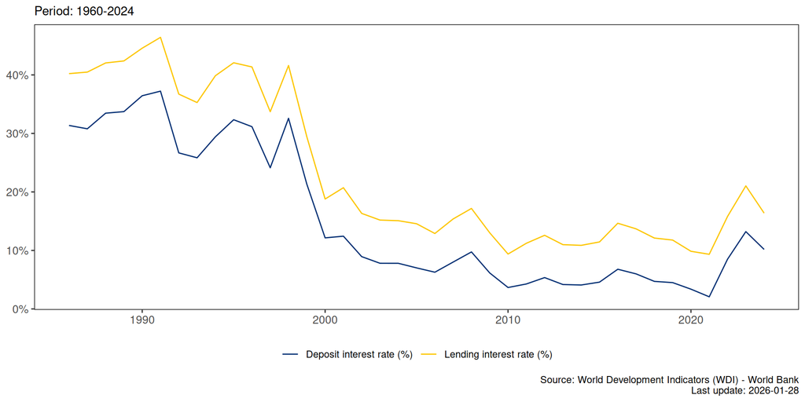

Figure 4: Deposit and lending interest rate in Colombia

# Acknowledgments

- To my family that supports me
- To the taxpayers of Colombia and the [**UMNG students**](https://www.umng.edu.co/estudiante) who pay my salary
- To the [**Business Science**](https://www.business-science.io/) and [**R4DS Online Learning**](https://www.rfordatasci.com/) communities where I learn [**R**](https://www.r-project.org/about.html) and [**$\pi$-thon**](https://www.python.org/about/)
- To the [**R Core Team**](https://www.r-project.org/contributors.html), the creators of [**RStudio IDE**](https://posit.co/download/rstudio-desktop/), [**Positron**](https://positron.posit.co/), [**Quarto**](https://quarto.org/) and the authors and maintainers of the packages [**tidyverse**](https://CRAN.R-project.org/package=tidyverse), [**scales**](https://CRAN.R-project.org/package=scales), [**readxl**](https://CRAN.R-project.org/package=readxl), [**janitor**](https://CRAN.R-project.org/package=janitor), [**gt**](https://CRAN.R-project.org/package=gt), [**tidyquant**](https://CRAN.R-project.org/package=tidyquant), [**wbstats**](https://CRAN.R-project.org/package=wbstats) and [**tinytex**](https://CRAN.R-project.org/package=tinytex) for allowing me to access these tools without paying for a license

# References

Cardenas, M. (2020). *Introducción a la Economía Colombiana* (4th ed.). Alfaomega.

Colombia, S. F. de. (2021). *Circular Básica Contable y Financiera (Circular Externa 100 de 1995)*. https://www.superfinanciera.gov.co/publicaciones/15466/normativanormativa-generalcircular-basica-contable-y-financiera-circular-externa-de-15466/

Freixas, X., & Rochet, J.-C. (2008). *Microeconomics of banking* (2nd ed). MIT Press.